# BDSI R Workshop - Applying Wrangling and Visualisation skills

Robert Cope & Terry Neeman

2022

```r
library(tidyverse)
library(janitor)
library(gtsummary)
```

In this exercise we will explore a recent published dataset, from this paper:

Marcato, F., van den Brand, H., Jansen, C. A., Rutten, V. P., Kemp, B., Engel, B., … & van Reenen, K. (2021). Effects of pre-transport diet, transport duration and transport condition on immune cell subsets, haptoglobin, cortisol and bilirubin in young veal calves. PloS one, 16(2), e0246959.

The aim of this study was to investigate effects of pre-transport diets (rearing milk OR electrolytes), transport durations (6 OR 18 hours) and transport conditions (open OR conditioned truck) on immune cell subsets, haptoglobin, cortisol and bilirubin of young calves upon arrival at the veal farm.

In this document, we create a workflow. First we read in the data. Then we do some data wrangling to put the data in a format that’s easy to visualise. The third step in the workflow is data visualisation. Data visualisation using ggplot2 is an essential part of understanding relevant patterns in the data.

## Read and clean up the data

```r
veal <- read_csv('data/Marcato_2021_immunity.csv')
glimpse(veal)
```

```
## Rows: 1,024
## Columns: 37
## $ Timepoint            <chr> "CC", "CC", "CC", "CC", "CC", "CC", "CC", "CC", "…
## $ Batch                <dbl> 1, 1, 1, 1, 1, 1, 1, 1, 1, 1, 1, 1, 1, 1, 1, 1, 1…
## $ Animal               <dbl> 1, 2, 3, 4, 5, 6, 7, 8, 9, 10, 11, 12, 13, 14, 15…
## $ Eartag               <dbl> 48454, 4796, 85085, 884, 59787, 73475, 73981, 454…
## $ Uplo                 <chr> "up", "up", "low", "low", "up", "up", "low", "low…
## $ Bafr                 <chr> "back", "back", "back", "back", "back", "back", "…
## $ Pen                  <dbl> 4, 4, 6, 6, 7, 7, 2, 2, 10, 10, 13, 13, 14, 14, 1…
## $ Corridor             <dbl> 1, 1, 1, 1, 1, 1, 1, 1, 2, 2, 2, 2, 2, 2, 2, 2, 3…
## $ Diet                 <chr> "E", "E", "M", "M", "E", "E", "M", "M", "E", "E",…
## $ Duration             <dbl> 6, 6, 6, 6, 6, 6, 6, 6, 6, 6, 6, 6, 6, 6, 6, 6, 6…
## $ Type                 <chr> "U", "U", "C", "C", "C", "C", "U", "U", "C", "C",…
## $ Bilirubin_1          <chr> "12.95", "18.51", "26.11", "9.84", "19.05", "4.60…
## $ Cortisol_1           <chr> "7.58", "16.55", "17.49", "12.37", "3.55", "4.46"…
```

[output cut: 24 more lines]

Many of the later columns here have spaces or punctuation that is awkward to work with. A convenient way of dealing with this is to use the clean_names() function from the janitor package.

```r
veal <- clean_names(veal)
glimpse(veal)
```

```
## Rows: 1,024
## Columns: 37
## $ timepoint        <chr> "CC", "CC", "CC", "CC", "CC", "CC", "CC", "CC", "CC",…
## $ batch            <dbl> 1, 1, 1, 1, 1, 1, 1, 1, 1, 1, 1, 1, 1, 1, 1, 1, 1, 1,…
## $ animal           <dbl> 1, 2, 3, 4, 5, 6, 7, 8, 9, 10, 11, 12, 13, 14, 15, 16…
## $ eartag           <dbl> 48454, 4796, 85085, 884, 59787, 73475, 73981, 45400, …
## $ uplo             <chr> "up", "up", "low", "low", "up", "up", "low", "low", "…
## $ bafr             <chr> "back", "back", "back", "back", "back", "back", "back…
## $ pen              <dbl> 4, 4, 6, 6, 7, 7, 2, 2, 10, 10, 13, 13, 14, 14, 15, 1…
## $ corridor         <dbl> 1, 1, 1, 1, 1, 1, 1, 1, 2, 2, 2, 2, 2, 2, 2, 2, 3, 3,…
## $ diet             <chr> "E", "E", "M", "M", "E", "E", "M", "M", "E", "E", "M"…
## $ duration         <dbl> 6, 6, 6, 6, 6, 6, 6, 6, 6, 6, 6, 6, 6, 6, 6, 6, 6, 6,…
## $ type             <chr> "U", "U", "C", "C", "C", "C", "U", "U", "C", "C", "U"…
## $ bilirubin_1      <chr> "12.95", "18.51", "26.11", "9.84", "19.05", "4.60", "…
## $ cortisol_1       <chr> "7.58", "16.55", "17.49", "12.37", "3.55", "4.46", "2…
```

[output cut: 24 more lines]

When we look at this output, we notice that some of the columns that we expect to be numbers, are not. If you look at the csv you notice that they have ‘.’ instead of empty cells where data are missing. Converting these to numeric will work (and turn those dots into NAs), but it will show a warning.

For example:

```r
veal$bilirubin_1 <- as.numeric(veal$bilirubin_1)
```

```
## Warning: NAs introduced by coercion
```

You can modify multiple columns at once using the function combination mutate(across()). Here is a helpful reference: https://dplyr.tidyverse.org/articles/colwise.html

```r
veal <- veal %>%
  mutate(across(c(cortisol_1:titer_ig_m), as.numeric))
```

## Initial checks of experimental setup

(reminder what our data now looks like)

```r
glimpse(veal)
```

```
## Rows: 1,024
## Columns: 37
## $ timepoint        <chr> "CC", "CC", "CC", "CC", "CC", "CC", "CC", "CC", "CC",…
## $ batch            <dbl> 1, 1, 1, 1, 1, 1, 1, 1, 1, 1, 1, 1, 1, 1, 1, 1, 1, 1,…
## $ animal           <dbl> 1, 2, 3, 4, 5, 6, 7, 8, 9, 10, 11, 12, 13, 14, 15, 16…
## $ eartag           <dbl> 48454, 4796, 85085, 884, 59787, 73475, 73981, 45400, …
## $ uplo             <chr> "up", "up", "low", "low", "up", "up", "low", "low", "…
## $ bafr             <chr> "back", "back", "back", "back", "back", "back", "back…
## $ pen              <dbl> 4, 4, 6, 6, 7, 7, 2, 2, 10, 10, 13, 13, 14, 14, 15, 1…
## $ corridor         <dbl> 1, 1, 1, 1, 1, 1, 1, 1, 2, 2, 2, 2, 2, 2, 2, 2, 3, 3,…
## $ diet             <chr> "E", "E", "M", "M", "E", "E", "M", "M", "E", "E", "M"…
## $ duration         <dbl> 6, 6, 6, 6, 6, 6, 6, 6, 6, 6, 6, 6, 6, 6, 6, 6, 6, 6,…
## $ type             <chr> "U", "U", "C", "C", "C", "C", "U", "U", "C", "C", "U"…
## $ bilirubin_1      <dbl> 12.95, 18.51, 26.11, 9.84, 19.05, 4.60, 8.35, 6.31, 7…
## $ cortisol_1       <dbl> 7.58, 16.55, 17.49, 12.37, 3.55, 4.46, 22.69, 5.84, 5…
```

[output cut: 24 more lines]

At the Collection Centre, calves were randomly allocated by the manager of the collection centre to one of eight treatment groups (N = 23 calves per treatment group per batch). Within each batch, 8 calves per treatment group were randomly selected for blood sampling. If we just use the data from the Collection Centre, can we check this?

```r
veal %>%
  filter(timepoint == "CC")%>%
  group_by(batch, diet,duration,type) %>%
  summarise(count = n()) %>%
  pivot_wider(names_from = batch, values_from = count)
```

```
## # A tibble: 8 × 5
## # Groups:   diet, duration [4]
##   diet  duration type    `1`   `2`
##   <chr>    <dbl> <chr> <int> <int>
## 1 E            6 C         8     8
## 2 E            6 U         8     8
## 3 E           18 C         8     8
## 4 E           18 U         8     8
## 5 M            6 C         8     8
## 6 M            6 U         8     8
## 7 M           18 C         8     8
## 8 M           18 U         8     8
```

It’s unclear from the data whether the animalID comes from the “eartag” or the “animal” column. In my mind, the “eartag” column sounds more like an ID name, but check out whether they are the same. From the code below, it appears that they don’t correspond at all! So for the future, we’ll use “eartag” as the animalID variable.

```r
veal %>%
   group_by(eartag, animal) %>%
   summarise(count = n()) %>%
   filter(count > 0)
```

```
## # A tibble: 401 × 3
## # Groups:   eartag [130]
##    eartag animal count
##     <dbl>  <dbl> <int>
##  1     93     17     2
##  2     93     18     1
##  3     93     41     5
##  4    366     69     2
##  5    366     70     1
##  6    366     99     3
##  7    366    126     2
##  8    884      4     2
##  9    884      6     3
## 10    884     11     1
## # … with 391 more rows
```

In our data set there are 8 rows per treatment per batch.(16 rows per treatment) Check that the column ‘eartag’ captures the data for each animal/timepoint.

```r
data_by_eartag <- veal %>%
  group_by(eartag, timepoint) %>%
  summarise(count = n()) %>%
  pivot_wider(names_from = timepoint, values_from = count)
data_by_eartag
```

```
## # A tibble: 130 × 9
## # Groups:   eartag [130]
##    eartag    CC    T0   T24    T4   T48 `Week 1` `Week 3` `Week 5`
##     <dbl> <int> <int> <int> <int> <int>    <int>    <int>    <int>
##  1     93     1     1     1     1     1        1        1        1
##  2    366     1     1     1     1     1        1        1        1
##  3    884     1     1     1     1     1        1        1        1
##  4    888     1     1     1     1     1        1        1        1
##  5    895     1     1     1     1     1        1        1        1
##  6    902     1     1     1     1     1        1        1        1
##  7    907     1     1     1     1     1        1        1        1
##  8   1564     1     1     1     1     1        1        1        1
##  9   1624     1     1     1     1     1        1        1        1
## 10   3568     1     1     1     1     1        1        1        1
## # … with 120 more rows
```

Summarise immune markers for each treatment combination of diet & duration at T24:

```r
veal %>%
  filter(timepoint == "T24") %>%
  mutate(treat = interaction(diet, duration)) %>%
  select(treat, bilirubin_1:titer_ig_m) %>%
  tbl_summary(by = treat)
```

| **Characteristic** | **E.6**, N = 32<sup>1</sup> | **M.6**, N = 32<sup>1</sup> | **E.18**, N = 32<sup>1</sup> | **M.18**, N = 32<sup>1</sup> |
| --- | --- | --- | --- | --- |
| bilirubin_1 | 3.64 (2.86, 5.14) | 4.60 (2.65, 6.23) | 3.75 (2.78, 4.61) | 3.47 (2.65, 4.44) |
| Unknown | 0 | 0 | 1 | 0 |
| cortisol_1 | 1.7 (0.7, 5.2) | 2.1 (0.7, 5.7) | 4.0 (1.1, 9.7) | 3.5 (0.7, 7.1) |
| Unknown | 2 | 7 | 3 | 5 |
| haptoglobin | 0.27 (0.23, 0.35) | 0.28 (0.21, 0.39) | 0.33 (0.24, 0.42) | 0.35 (0.26, 0.57) |
| Unknown | 0 | 0 | 1 | 0 |
| titer_ig_g | 4.30 (3.48, 5.18) | 4.60 (3.20, 5.05) | 4.50 (3.60, 5.70) | 4.50 (3.08, 5.03) |
| Unknown | 0 | 0 | 1 | 0 |
| titer_ig_m | 4.70 (3.88, 5.95) | 4.70 (3.85, 5.93) | 4.95 (3.70, 5.53) | 5.15 (4.70, 5.82) |

<sup>1</sup> Median (IQR)

## Exploratory plots

We approach data exploration from a research question perspective. The main questions of interest were in understanding the effect of calf handling/diet on immune cell subsets, haptoglobin, cortisol and bilirubin of young calves upon arrival at the veal farm. In this workflow, we focus on cortisol and CD8 cells. Similar exploratory plots can be done for the other markers.

What is the effect of diet on cortisol levels? At this point, we may want to indicate that M = milk and E = electrolytes. We can also make M the reference level.

```r
veal <- mutate(veal, diet = factor(diet,
                                        levels = c("M","E"),
                                        labels = c("Milk","Electrolytes")))
```

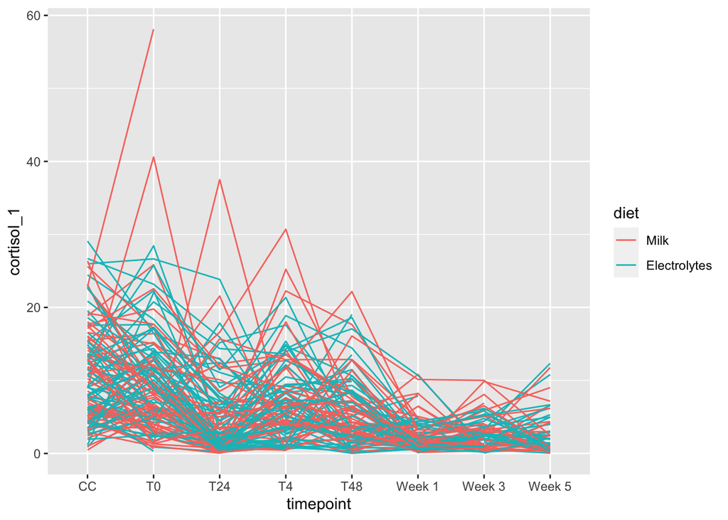

```r
ggplot(veal, aes(x=timepoint, y = cortisol_1,colour = diet))+
  geom_line(aes(group = eartag))
```

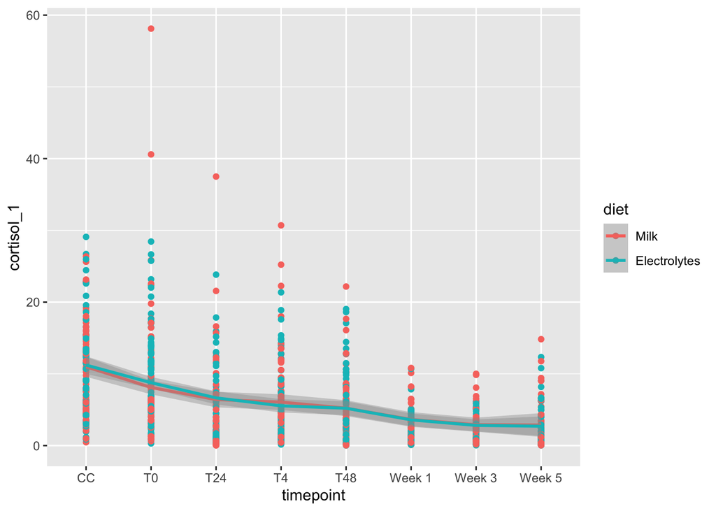

```r
ggplot(veal, aes(x=timepoint, y = cortisol_1, group = diet,colour = diet))+
  geom_point() +
  geom_smooth()
```

What do you notice is wrong with this plot?

The x axis is in the wrong order! you can fix this using factor() and specifying the levels.

Fix the factor levels and remake the plot (just paste the plot code again).

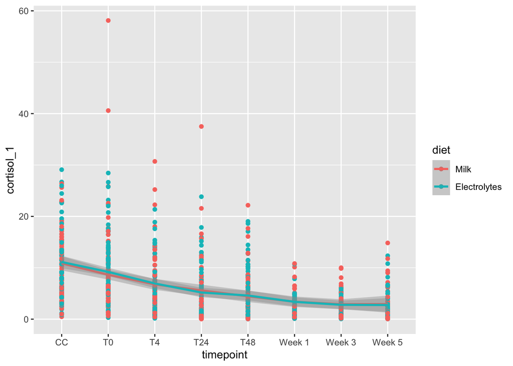

```r
veal$timepoint <- factor(veal$timepoint, levels = c('CC',
                                                    'T0',
                                                    'T4',
                                                    'T24',
                                                    'T48',
                                                    'Week 1',
                                                    'Week 3',
                                                    'Week 5'))

ggplot(veal, aes(x=timepoint, y = cortisol_1, group = diet, colour = diet))+
  geom_point() +
 geom_smooth()
```

There may be a diet effect at the early time points, but there is a lot of variation in the data. Split these data into the 4 subplots: one for each transport and transport time factor.

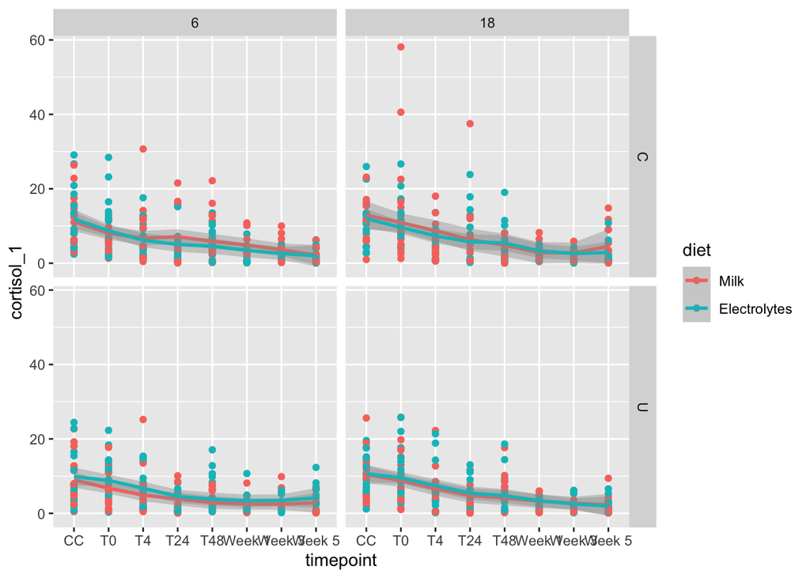

```r
ggplot(veal, aes(x=timepoint, y = cortisol_1, group=diet, colour = diet))+
  geom_point() +
 geom_smooth() +
  facet_grid(type~duration)
```

We can also look at the smoothed curves without the data. This will change the y-axis limits. Does this perspective change your assessment?

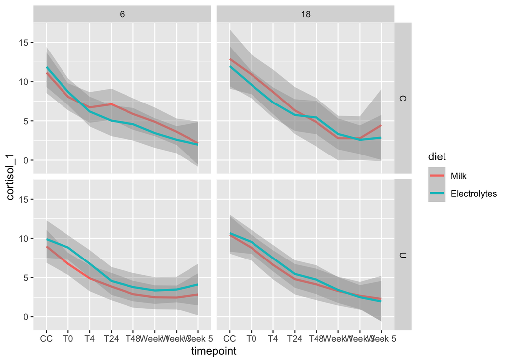

```r
ggplot(veal, aes(x=timepoint, y = cortisol_1, group=diet, colour = diet))+
  #geom_point() +
 geom_smooth() +
  facet_grid(type~duration)
```

Now look at the duration of transport effect for each diet:transport type combination.

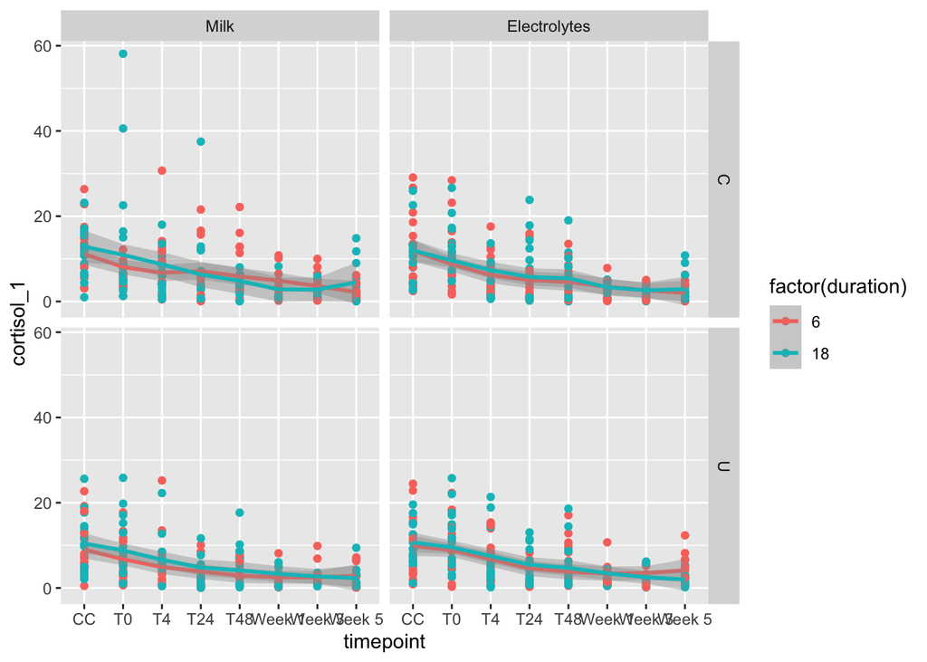

```r
ggplot(veal, aes(x=timepoint, y = cortisol_1, group=factor(duration), colour = factor(duration)))+
  geom_point() +
 geom_smooth() +
  facet_grid(type~diet)
```

Finally, look at the effect of transport type on cortisol levels, for each diet and transport duration.

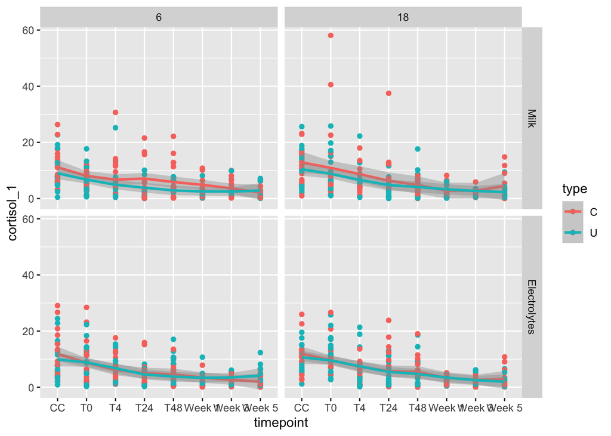

```r
ggplot(veal, aes(x=timepoint, y = cortisol_1, group=type, colour = type))+
  geom_point() +
 geom_smooth() +
  facet_grid(diet~duration)
```

What are the patterns you see in these data?

## FACS data

(reminder what our data now looks like)

```r
str(veal)
```

```
## tibble [1,024 × 37] (S3: tbl_df/tbl/data.frame)
##  $ timepoint       : Factor w/ 8 levels "CC","T0","T4",..: 1 1 1 1 1 1 1 1 1 1 ...
##  $ batch           : num [1:1024] 1 1 1 1 1 1 1 1 1 1 ...
##  $ animal          : num [1:1024] 1 2 3 4 5 6 7 8 9 10 ...
##  $ eartag          : num [1:1024] 48454 4796 85085 884 59787 ...
##  $ uplo            : chr [1:1024] "up" "up" "low" "low" ...
##  $ bafr            : chr [1:1024] "back" "back" "back" "back" ...
##  $ pen             : num [1:1024] 4 4 6 6 7 7 2 2 10 10 ...
##  $ corridor        : num [1:1024] 1 1 1 1 1 1 1 1 2 2 ...
##  $ diet            : Factor w/ 2 levels "Milk","Electrolytes": 2 2 1 1 2 2 1 1 2 2 ...
##  $ duration        : num [1:1024] 6 6 6 6 6 6 6 6 6 6 ...
##  $ type            : chr [1:1024] "U" "U" "C" "C" ...
##  $ bilirubin_1     : num [1:1024] 12.95 18.51 26.11 9.84 19.05 ...
##  $ cortisol_1      : num [1:1024] 7.58 16.55 17.49 12.37 3.55 ...
##  $ haptoglobin     : num [1:1024] 0.31 0.28 0.18 0.55 0.17 0.15 0.2 0.18 0.27 0.19 ...
```

[output cut: 23 more lines]

The FACS was only done at timepoints CC and T0, so we just want to work with those times.

Filter the dataset to get just those timepoints, store this with the name veal_start.

```r
veal_start <- veal %>% filter(timepoint %in% c('CC','T0'))
```

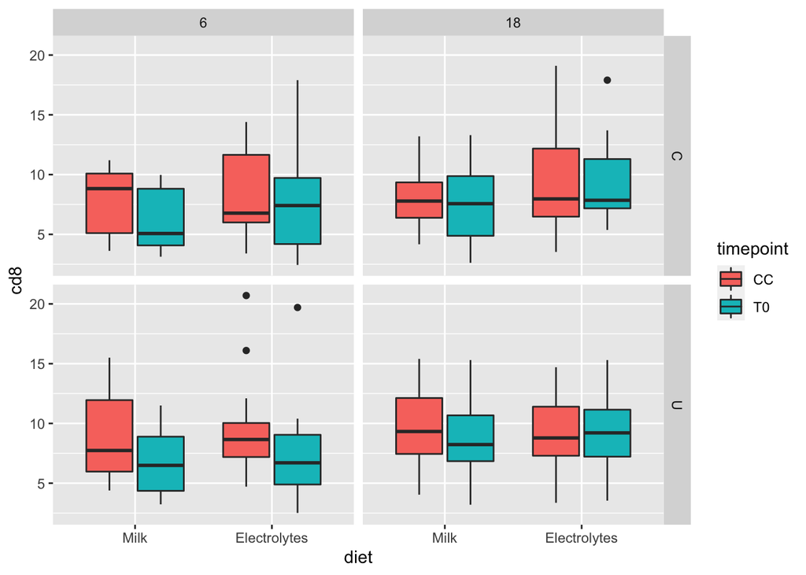

```r
ggplot(veal_start, aes(x=diet, y=cd8,fill= timepoint))+
  geom_boxplot()+
  facet_grid(type~duration)
```

At the Collection Centre time, we expect the CD8 levels to have the same distribution for each treatment group since these are baseline measurements. If there were an effect of diet on CD8 levels, one would expect to see within-animal changes between CC and T0 to be different by diet.

Graph the within-animal changes over time.

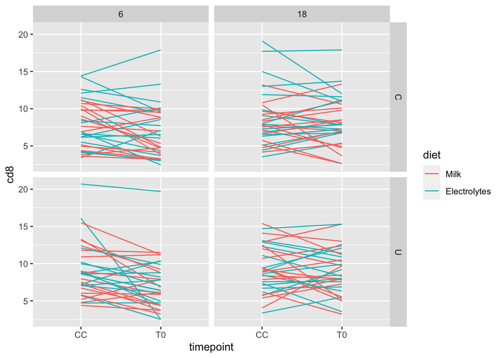

```r
ggplot(veal_start, aes(x=timepoint, y=cd8,col=diet,group=eartag))+
  geom_line()+
  facet_grid(type~duration)
```

It does look like there is something happening here, but it is difficult to diagnose like this. Something that might be more informative is the change in cd8 between time CC and time T0.

We can do this, but it needs something a little complicated: a function called pivot_wider(). We will look at how to do this in more detail in the next workshop, for now you should work from / edit this example:

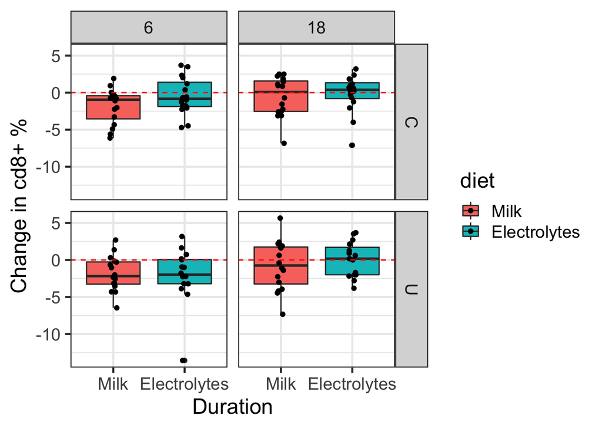

```r
veal_diff <- veal_start %>%
  select(eartag,diet,duration,type,timepoint,cd8) %>%
  pivot_wider(names_from = timepoint,
              values_from = cd8) %>%
  mutate(change_in_cd8 = T0 - CC)

  ggplot(veal_diff, aes(x=diet,y=change_in_cd8, fill=diet))+
  geom_boxplot()+
  geom_point(position = position_jitterdodge(jitter.width = 0.2))+
  geom_hline(yintercept = 0,col='red',lty='dashed')+
  xlab('Duration')+ylab('Change in cd8+ %')+
  theme_bw(base_size = 18)+
  facet_grid(type~duration)
```

## Exercise

Describe an experiment that your lab has done, including relevant background information.

Import your data and include some descriptive summaries.

Use ggplot to explore your research questions visually.